# Unit 11 For Live Session

Chad Madding

March 15, 2020

## Unit 11 For Live Session

**In preparation for the live session, please complete the following. Be sure and submit your work to the “Unit 11:”For Live Session" Assignment" assignment on 2DS:**

Please address each activity on at least one PowerPoint slide and submit via the online campus. Our purpose is to update the Sunspot analysis. Download the most current yearly mean sunspot data and with this data:

#### 1. Plot the data.

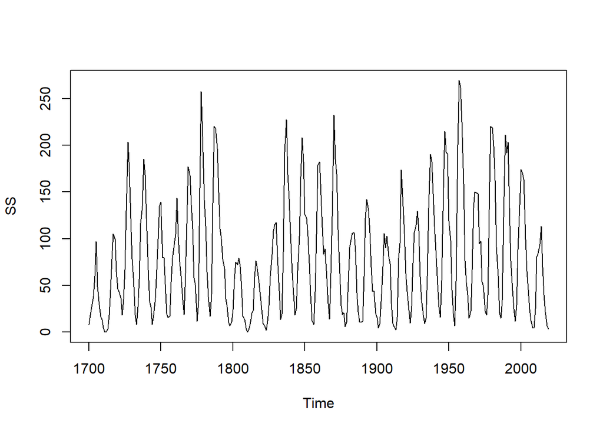

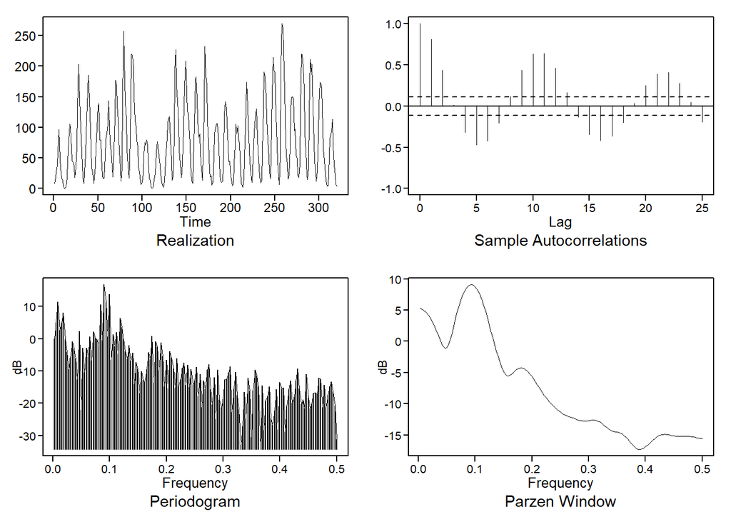

#### 2. Comment on its stationarity.

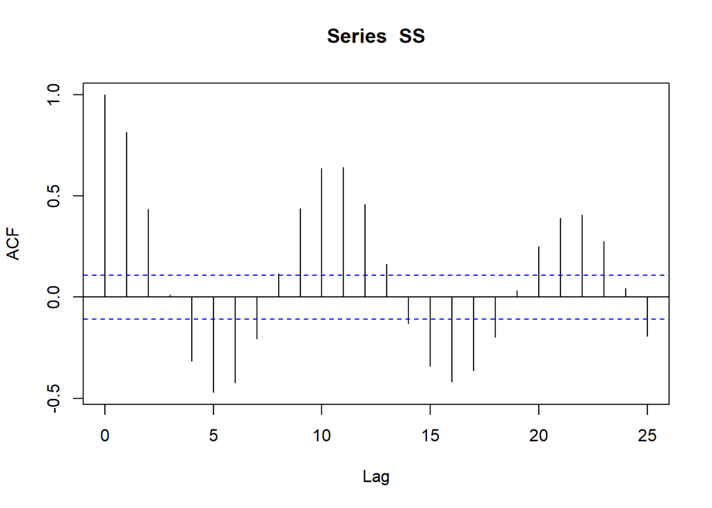

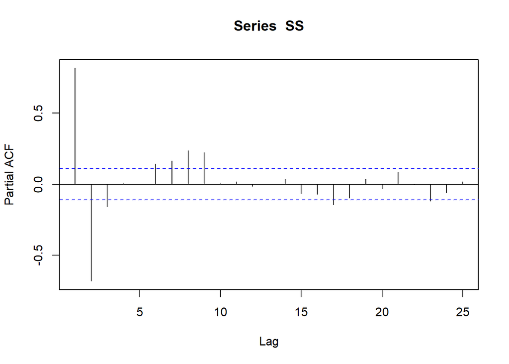

```r
adf.test(SS)
```

```
##
##  Augmented Dickey-Fuller Test
##
## data:  SS
## Dickey-Fuller = -5.2163, Lag order = 6, p-value = 0.01
## alternative hypothesis: stationary
```

#### 3. Use aic5.wge to estimate the p and q of the model. You may use your choice of AIC/AICC/BIC.

```r
#Checking the AIC options
aic5.wge(SS,p=0:15,q=0:2,type="aic")
```

```
## ---------WORKING... PLEASE WAIT...
##
##
## Five Smallest Values of  aic
```

```
##       p    q        aic
## 28    9    0   6.363586
## 48   15    2   6.364225
## 29    9    1   6.369581
## 31   10    0   6.369614
## 47   15    1   6.372261
```

```r
aic5.wge(SS,p=0:15,q=0:2,type="aicc")
```

```
## ---------WORKING... PLEASE WAIT...
##
##
## Five Smallest Values of  aicc
```

```
##       p    q        aicc
## 28    9    0    7.372515
## 48   15    2    7.378391
## 29    9    1    7.379007
## 31   10    0    7.379040
## 30    9    2    7.385611
```

```r
aic5.wge(SS,p=0:15,q=0:2,type="bic")
```

```
## ---------WORKING... PLEASE WAIT...
##
##
## Five Smallest Values of  bic
```

```
##       p    q        bic
## 28    9    0   6.481346
## 23    7    1   6.492549
## 26    8    1   6.495733
## 24    7    2   6.496244
## 29    9    1   6.499117
```

All the AIC’s point to and AR(9).

```r
#playing around with the Forcast package to see what it picks
#differencing needed to stationarize the series
ndiffs(SS)
```

```
## [1] 0
```

```r
SSAA=auto.arima(SS,stepwise = FALSE,  approximation=FALSE, seasonal = TRUE, stationary = TRUE)
SSAA
```

```
## Series: SS
## ARIMA(3,0,0) with non-zero mean
##
## Coefficients:
##          ar1      ar2      ar3     mean
##       1.2837  -0.4927  -0.1439  78.7834
## s.e.  0.0553   0.0864   0.0554   4.0336
##
## sigma^2 estimated as 654.6:  log likelihood=-1490.74
## AIC=2991.47   AICc=2991.67   BIC=3010.32
```

```r
forecast(SSAA, h=15)
```

```
##      Point Forecast      Lo 80     Hi 80      Lo 95     Hi 95
## 2020       25.85025  -6.939628  58.64012 -24.297540  75.99804
## 2021       58.20164   4.845956 111.55733 -23.398839 139.80212
## 2022       89.25696  23.824358 154.68956 -10.813568 189.32749
## 2023      109.98226  40.569705 179.39482   3.824918 216.13960
## 2024      116.63282  47.038794 186.22686  10.197940 223.06771
## 2025      110.49191  40.122955 180.86087   2.871880 218.11194
## 2026       96.35122  23.416377 169.28607 -15.192998 207.89544
## 2027       80.26813   4.585930 155.95032 -35.477805 196.01406
## 2028       67.47293  -9.680075 144.62593 -50.522407 185.46826
## 2029       61.00599 -16.423068 138.43504 -57.411534 179.42351
## 2030       61.32196 -16.130595 138.77452 -57.131501 179.77542
## 2031       66.75420 -11.092537 144.60094 -52.302110 185.81051
## 2032       74.50195  -3.989968 152.99386 -45.541077 194.54497
## 2033       81.72568   2.746123 160.70523 -39.063128 202.51448
## 2034       86.40001   7.251079 165.54894 -34.647833 207.44785
```

#### 4. Fit the model using your model identification (p and q). You may use any of the estimates you like (maximum likelihood, Yule-Walker, Burg).

I am choosing to go with the AR(3) model from the auto.arima.

```r
#Maximum Likelihood Estimation
SS3.mle=est.ar.wge(SS,p=3,type='mle')
```

```
##
## Coefficients of Original polynomial:
## 1.2837 -0.4927 -0.1439
##
## Factor                 Roots                Abs Recip    System Freq
## 1-1.4709B+0.7681B^2    0.9575+-0.6206i      0.8764       0.0915
## 1+0.1873B             -5.3398               0.1873       0.5000
##
##
##
## Coefficients of Original polynomial:
## 1.2837 -0.4927 -0.1439
##
## Factor                 Roots                Abs Recip    System Freq
## 1-1.4709B+0.7681B^2    0.9575+-0.6206i      0.8764       0.0915
## 1+0.1873B             -5.3398               0.1873       0.5000
##
##
```

```r
mean(SS) #[1] 78.735
```

```
## [1] 78.735
```

```r
SS3.mle$avar #[1] 644.4032
```

```
## [1] 644.4032
```

```r
#Yule Walker Estimate
#SS.yw=est.ar.wge(SS,p=9,type='yw')
#Burg Estimates
#SS.burg=est.ar.wge(SS,p=9,type='burg')
```

** Final AR(3) model**

$$(1-1.28B+0.49B^2+0.14B^3)(x_t-78.74)=a_y\ \sigma^2_a=644.4$$

#### 5. Use this model to generate an ASE from forecasting the last 15 years of sunspot data.

```r
SS3.mle.est = fore.arma.wge(SS, phi = SS3.mle$phi, theta = 0,lastn = T, n.ahead = 15)
```

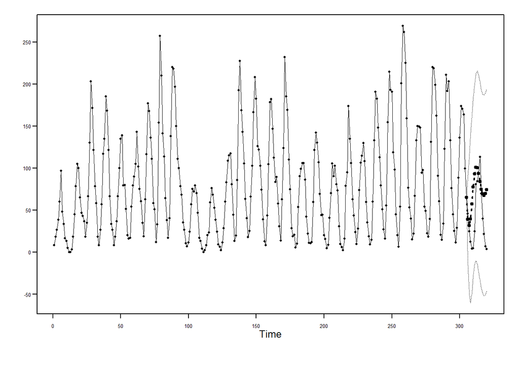

```r
SS3.mle.ase = mean((SS[(320-15+1):320] - SS3.mle.est$f)^2)
SS3.mle.ase
```

```
## [1] 1802.668
```

```r
#SS.mle.est = fore.arma.wge(SS, phi = SS.mle$phi, theta = 0,lastn = T, n.ahead = 15)
#SS.mle.ase = mean((SS[(320-15+1):320] - SS.mle.est$f)^2)
#SS.mle.ase
#SS.yw.est = fore.arma.wge(SS, phi = SS.yw$phi, theta = 0,lastn = T, n.ahead = 15)
#SS.yw.ase = mean((SS[(176-15+1):176] - SS.yw.est$f)^2)
#SS.yw.ase
#SS.burg.est = fore.arma.wge(SS, phi = SS.burg$phi, theta = 0,lastn = T, n.ahead = 15)
#SS.burg.ase = mean((SS[(176-15+1):176] - SS.burg.est$f)^2)
#SS.burg.ase
```

#### 6. Now fit a seasonal model to the Sunspot data (you pick the value of s), and find the ASE for this model using the last 15 years of sunspot data.

**Non Stationary**

```r
SS.overfit=est.ar.wge(SS,p = 12) #overfit for seasonality
```

```
##
## Coefficients of Original polynomial:
## 1.1602 -0.4099 -0.1310 0.1024 -0.0707 0.0122 0.0200 -0.0421 0.2102 -0.0023 0.0208 -0.0069
##
## Factor                 Roots                Abs Recip    System Freq
## 1-1.6144B+0.9473B^2    0.8521+-0.5741i      0.9733       0.0944
## 1-0.9449B              1.0583               0.9449       0.0000
## 1-0.6212B+0.7085B^2    0.4384+-1.1042i      0.8417       0.1899
## 1+1.4596B+0.6025B^2   -1.2112+-0.4389i      0.7762       0.4447
## 1+0.5472B+0.5428B^2   -0.5040+-1.2602i      0.7368       0.3106
## 1+0.2392B+0.1471B^2   -0.8129+-2.4769i      0.3836       0.3005
## 1-0.2258B              4.4289               0.2258       0.0000
##
##
##
## Coefficients of Original polynomial:
## 1.1602 -0.4099 -0.1310 0.1024 -0.0707 0.0122 0.0200 -0.0421 0.2102 -0.0023 0.0208 -0.0069
##
## Factor                 Roots                Abs Recip    System Freq
## 1-1.6144B+0.9473B^2    0.8521+-0.5741i      0.9733       0.0944
## 1-0.9449B              1.0583               0.9449       0.0000
## 1-0.6212B+0.7085B^2    0.4384+-1.1042i      0.8417       0.1899
## 1+1.4596B+0.6025B^2   -1.2112+-0.4389i      0.7762       0.4447
## 1+0.5472B+0.5428B^2   -0.5040+-1.2602i      0.7368       0.3106
## 1+0.2392B+0.1471B^2   -0.8129+-2.4769i      0.3836       0.3005
## 1-0.2258B              4.4289               0.2258       0.0000
##
##
```

```r
#(1-B^11)
factor.wge(c(rep(0,11),1))
```

```
##
## Coefficients of Original polynomial:
## 0.0000 0.0000 0.0000 0.0000 0.0000 0.0000 0.0000 0.0000 0.0000 0.0000 0.0000 1.0000
##
## Factor                 Roots                Abs Recip    System Freq
## 1-1.0000B+1.0000B^2    0.5000+-0.8660i      1.0000       0.1667
## 1-1.0000B              1.0000               1.0000       0.0000
## 1-1.7321B+1.0000B^2    0.8660+-0.5000i      1.0000       0.0833
## 1+1.0000B+1.0000B^2   -0.5000+-0.8660i      1.0000       0.3333
## 1-0.0000B+1.0000B^2    0.0000+-1.0000i      1.0000       0.2500
## 1+1.7321B+1.0000B^2   -0.8660+-0.5000i      1.0000       0.4167
## 1+1.0000B             -1.0000               1.0000       0.5000
##
##
```

#### Transform

Base on the overfit table we can now transform the data to remove the seasonality.

Transform data to create $Y_t=(1-B^{11})X_t$

```r
#rep will repeat the 11 zeros then we can add a one at the end
SS_11 = artrans.wge(SS,phi.tr = c(rep(0,10),1))
```

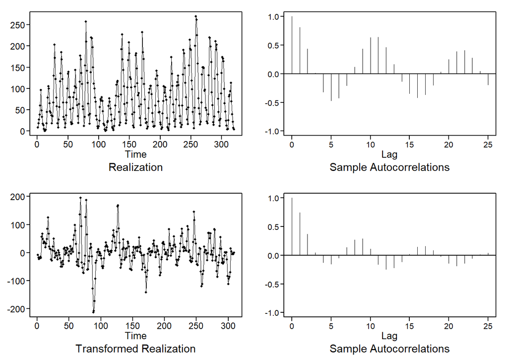

The transformed data appear stationary, so we use AIC to identify a model.

We use **aic5.wge** to model the transformed data  
When using AIC to model data that has been stationarized using the seasonal transform $(1-B^{11})$, it is good practice to allow a range of p values to include s to uncover any seasonal stationary information that might be in the data.

```r
aic5.wge(SS_11)
```

```
## ---------WORKING... PLEASE WAIT...
##
##
## Five Smallest Values of  aic
```

```
##       p    q        aic
## 7     2    0   6.887304
## 10    3    0   6.887733
## 8     2    1   6.888868
## 17    5    1   6.891418
## 11    3    1   6.892557
```

```r
aic5.wge(SS_11, type = "bic")
```

```
## ---------WORKING... PLEASE WAIT...
##
##
## Five Smallest Values of  bic
```

```
##       p    q        bic
## 7     2    0   6.923550
## 10    3    0   6.936061
## 8     2    1   6.937196
## 11    3    1   6.952967
## 13    4    0   6.953157
```

**Seasonal ARMA(2,0) s = 11**

AIC selects an AR(2,0) model. Factoring the ARMA(2,0) model we obtain:

```r
AR2 = est.arma.wge(SS_11,p = 2,q = 0)
```

```
##
## Coefficients of Original polynomial:
## 1.0658 -0.4282
##
## Factor                 Roots                Abs Recip    System Freq
## 1-1.0658B+0.4282B^2    1.2446+-0.8868i      0.6544       0.0985
##
##
```

```r
SS_11_AR2 = artrans.wge(SS_11,AR2$phi)
```

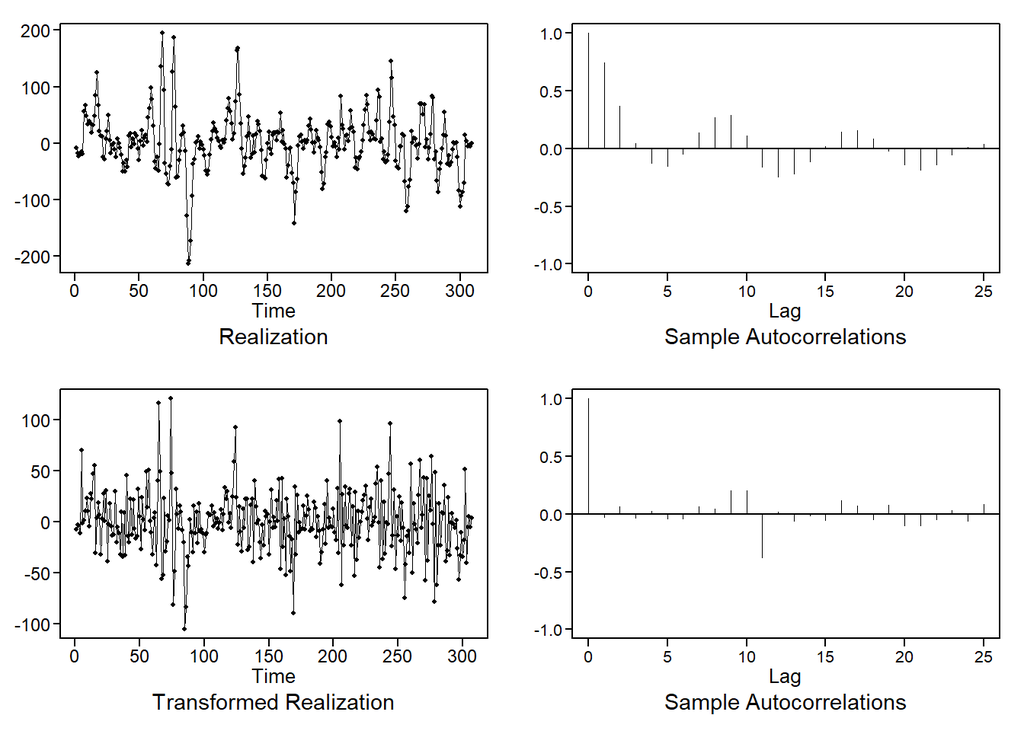

```r
ljung.wge(SS_11_AR2)
```

```
## Obs -0.03029242 0.06498946 -0.03054033 0.02616251 -0.04295413 -0.0379189 0.06815614 0.04558587 0.2051407 0.2058483 -0.3755154 0.0178266 -0.06186141 -0.01487119 -0.05151079 0.1196943 0.06923265 -0.0445448 0.07863812 -0.1030653 -0.09716369 -0.0462077 0.0338844 -0.06027784
```

```
## $test
## [1] "Ljung-Box test"
##
## $K
## [1] 24
##
## $chi.square
## [1] 97.53852
##
## $df
## [1] 24
##
## $pval
## [1] 7.872403e-11
```

```r
ljung.wge(SS_11_AR2, K = 48)
```

[output not shown]

```
## $test
## [1] "Ljung-Box test"
##
## $K
## [1] 48
##
## $chi.square
## [1] 138.7895
##
## $df
## [1] 48
##
## $pval
## [1] 9.349022e-11
```

```r
f = fore.aruma.wge(SS,s = 11,phi = AR2$phi,n.ahead = 15,limits = F,lastn = TRUE)
```

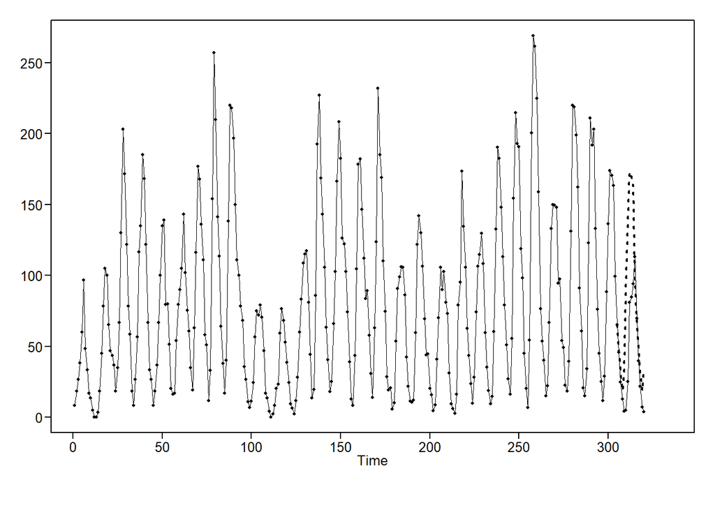

```r
SS_11_AR2.ASE = mean((SS[(length(SS)-14):length(SS)] - f$f)^2)

SS_11_AR2.ASE
```

```
## [1] 2828.898
```

#### 7. Describe which model you prefer, and why.

The best model turned out to be the AR(3) that auto.arima from the Forecast package picked. The ASE was also lower than the seasonal model. This was a stationary model to start with and that could have lead to the better performance.

#### 8. Use your best model (the one you choose) to forecast the next 10 years of sunspot data.

**Final AR(3) model**

$$(1-1.28B+0.49B^2+0.14B^3)(x_t-78.74)=a_y\ \sigma^2_a=644.4$$

```r
SS3.f = fore.arma.wge(SS,phi = SS3.mle$phi,theta = 0, n.ahead = 10,limits = F, lastn = F)
```

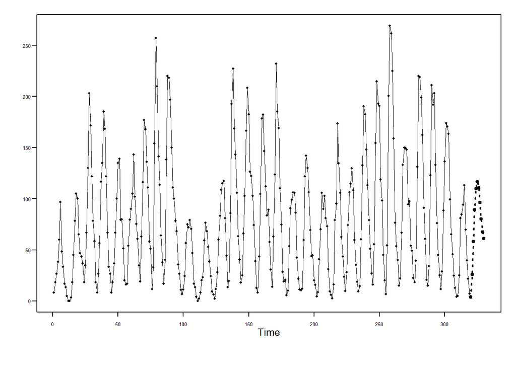

#### Analysis of AcuSpike Web Hits

Given what you have learned so far, model the Accuspike web page hits data, and provide the desired forecasts.  
This does not need to be a formal analysis with a write-up.  
You should be able to explore the data, identify a model, estimate the model, judge the appropriateness of the model, and provide the forecasts.

#### Plot the Data

```r
AS = read.csv("accuspike.csv",header = TRUE)
#Convert to a time series
AS = ts(AS$Active.Users)
```

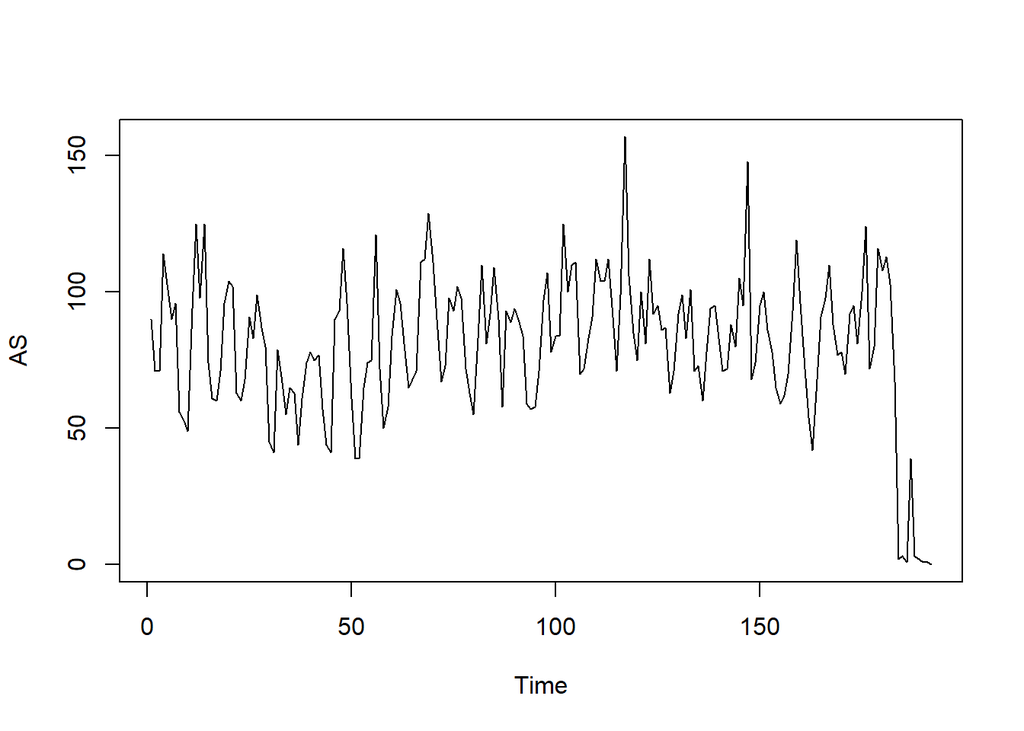

```r
#A simple plot of the data
plot(AS)
```

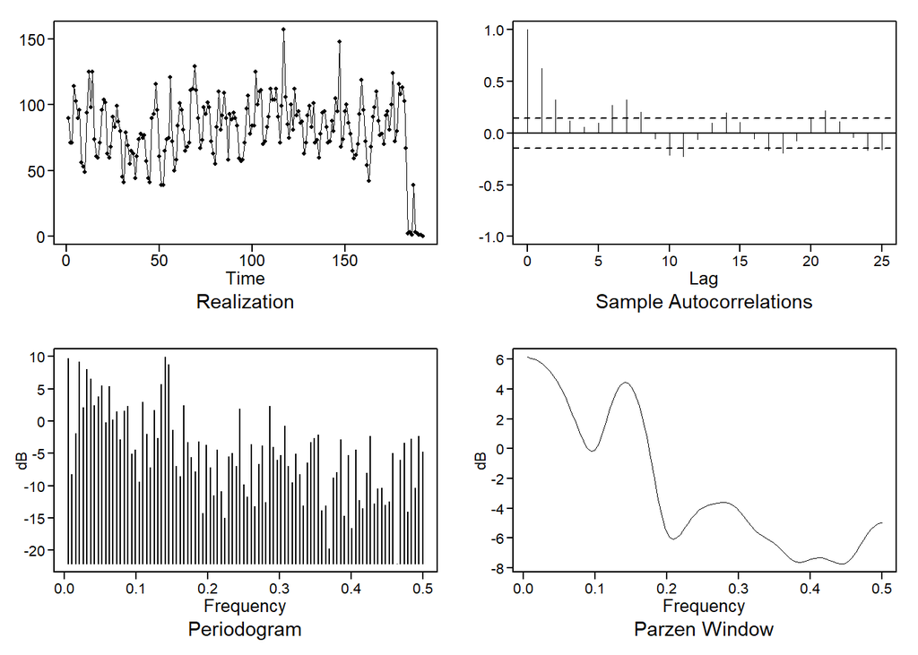

```
## $autplt
##  [1]  1.00000000  0.62988010  0.32605516  0.11724172  0.05853230  0.09502224
##  [7]  0.26720075  0.32572460  0.20160161 -0.05589477 -0.20965996 -0.22547446
## [13] -0.06329814  0.09792376  0.19963264  0.10497351 -0.05600133 -0.16683179
## [19] -0.19080221 -0.07439083  0.13842523  0.21987990  0.11138830 -0.03782526
## [25] -0.16355361 -0.15822851
##
## $freq
##  [1] 0.005208333 0.010416667 0.015625000 0.020833333 0.026041667 0.031250000
##  [7] 0.036458333 0.041666667 0.046875000 0.052083333 0.057291667 0.062500000
## [13] 0.067708333 0.072916667 0.078125000 0.083333333 0.088541667 0.093750000
## [19] 0.098958333 0.104166667 0.109375000 0.114583333 0.119791667 0.125000000
## [25] 0.130208333 0.135416667 0.140625000 0.145833333 0.151041667 0.156250000
## [31] 0.161458333 0.166666667 0.171875000 0.177083333 0.182291667 0.187500000
## [37] 0.192708333 0.197916667 0.203125000 0.208333333 0.213541667 0.218750000
```

[output cut: 45 more lines]

```r
#Plot Data, Sample Autocorrelations, Periodogram, and Parzen Spectral Estimate
plotts.sample.wge(AS, arlimits = TRUE)
```

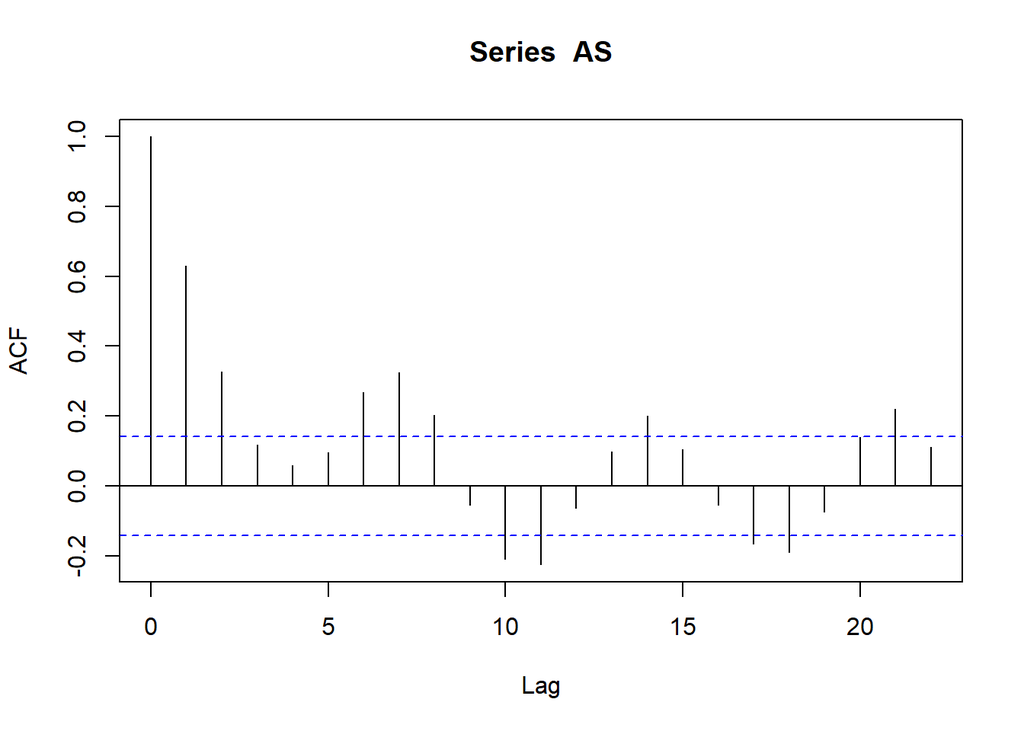

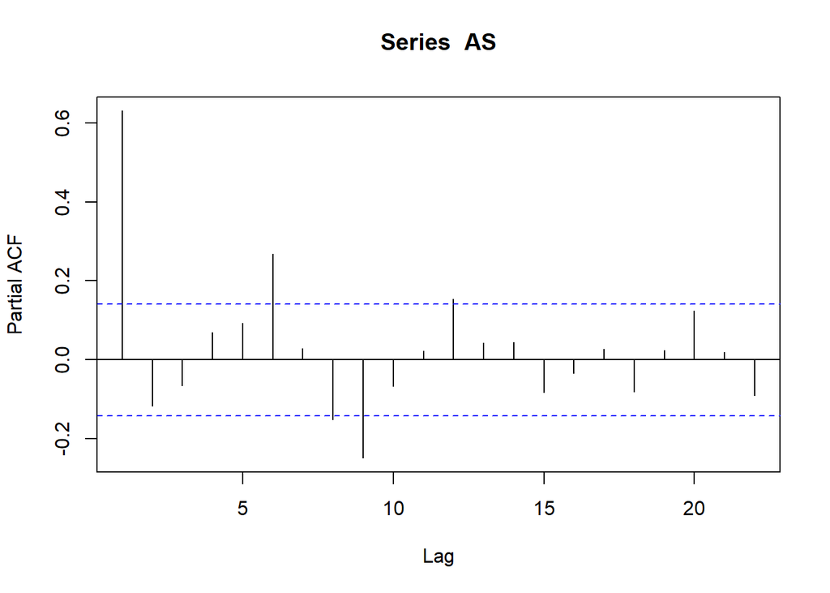

```r
adf.test(AS)
```

```
##
##  Augmented Dickey-Fuller Test
##
## data:  AS
## Dickey-Fuller = -1.3563, Lag order = 5, p-value = 0.8455
## alternative hypothesis: stationary
```

```r
#Checking the AIC options
aic5.wge(AS)
```

```
## ---------WORKING... PLEASE WAIT...
##
##
## Five Smallest Values of  aic
```

```
##       p    q        aic
## 17    5    1   6.009981
## 14    4    1   6.019087
## 7     2    0   6.039300
## 4     1    0   6.040475
## 5     1    1   6.041323
```

```r
#Use the Forcast package to see what it picks
#differencing needed to stationarize the series
ndiffs(AS)
```

```
## [1] 0
```

```r
ASAA=auto.arima(AS,stepwise = FALSE,  approximation=FALSE)
ASAA
```

```
## Series: AS
## ARIMA(4,0,1) with non-zero mean
##
## Coefficients:
##          ar1      ar2      ar3     ar4      ma1     mean
##       1.3614  -0.5114  -0.1159  0.2081  -0.6585  76.7454
## s.e.  0.1281   0.1443   0.1228  0.0759   0.1140   8.4863
##
## sigma^2 estimated as 398.9:  log likelihood=-844.82
## AIC=1703.65   AICc=1704.26   BIC=1726.45
```

```r
ASAA.f=forecast(ASAA, h=14)
```

The forecast package picked a ARMA(4,1) and that matches one to the AIC5’s so we will be using the (4,1).

```r
#Fit with 4,1
AS41=est.arma.wge(AS,p=4,q=1,factor = TRUE)
```

```
##
## Coefficients of Original polynomial:
## 1.3614 -0.5114 -0.1159 0.2081
##
## Factor                 Roots                Abs Recip    System Freq
## 1-0.9366B              1.0676               0.9366       0.0000
## 1-0.8693B+0.4998B^2    0.8695+-1.1156i      0.7070       0.1446
## 1+0.4445B             -2.2498               0.4445       0.5000
##
##
```

```r
AS41$phi #[1]  1.3614265 -0.5113544 -0.1158767  0.2080940
```

```
## [1]  1.3614265 -0.5113544 -0.1158767  0.2080940
```

```r
AS41$theta #[1] 0.6585371
```

```
## [1] 0.6585371
```

```r
mean(AS) #[1] 80.35
```

```
## [1] 80.35417
```

```r
AS41$avar #[1] 386.29
```

```
## [1] 386.2893
```

**Final ARMA(4,1) model**

$$(1-1.36B+0.51B^2+0.12B^3-0.21B^4)(x_t-80.35)=(1-0.66B)a_y\ \sigma^2_a=386.29$$
Forecast out two weeks

```r
AS41.f = fore.arma.wge(AS,phi = AS41$phi,theta = AS41$theta, n.ahead = 14,limits = F, lastn = F)
```

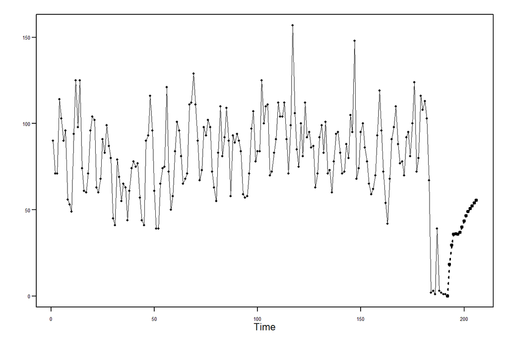

```r
AS41.f$f
```

```
##  [1] 18.24321 29.56630 35.76898 36.10131 35.86620 37.01370 39.94839 43.45338
##  [9] 46.54260 48.85478 50.62750 52.22999 53.88009 55.58287
```

```r
ASAA.f
```

```
##     Point Forecast      Lo 80    Hi 80      Lo 95     Hi 95
## 193       17.63329 -7.9622815 43.22887 -21.511761  56.77835
## 194       28.52767 -2.7581762 59.81353 -19.319905  76.37525
## 195       34.45859  1.1588219 67.75835 -16.469009  85.38619
## 196       34.71082  1.2418479 68.17979 -16.475555  85.89719
## 197       34.42839  0.9005688 67.95621 -16.847989  85.70477
## 198       35.49471  1.7942439 69.19517 -16.045705  87.03512
## 199       38.29580  4.1321551 72.45945 -13.952987  90.54459
## 200       41.64923  6.8986003 76.39986 -11.497273  94.79574
## 201       44.60000  9.3669574 79.83304  -9.284287  98.48428
## 202       46.79977 11.2523219 82.34721  -7.565359 101.16489
## 203       48.48001 12.7213448 84.23868  -6.208151 103.16818
## 204       49.99859 14.0669338 85.93024  -4.954134 104.95131
## 205       51.56594 15.4669098 87.66498  -3.642764 106.77465
## 206       53.18632 16.9219937 89.45064  -2.275178 108.64781
```

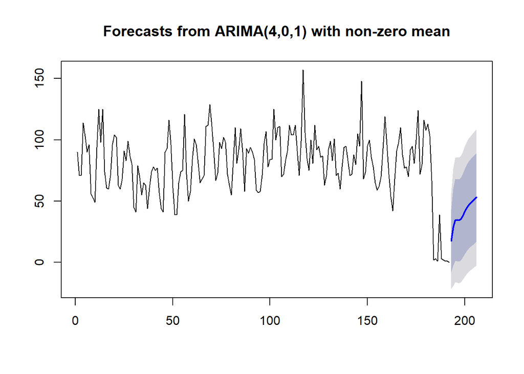

```r
plot(ASAA.f)
```